# Course Project 1

Pribylov V.A.

20 07 2020

# Introduction

It is now possible to collect a large amount of data about personal movement using activity monitoring devices such as a Fitbit, Nike Fuelband, or Jawbone Up. These type of devices are part of the “quantified self” movement – a group of enthusiasts who take measurements about themselves regularly to improve their health, to find patterns in their behavior, or because they are tech geeks. But these data remain under-utilized both because the raw data are hard to obtain and there is a lack of statistical methods and software for processing and interpreting the data.

This assignment makes use of data from a personal activity monitoring device. This device collects data at 5 minute intervals through out the day. The data consists of two months of data from an anonymous individual collected during the months of October and November, 2012 and include the number of steps taken in 5 minute intervals each day.

# Launch packages

```r
## R version 3.6.0 (2019-04-26)
## Platform: x86_64-w64-mingw32/x64 (64-bit)
## Running under: Windows 7 x64 (build 7601) Service Pack 1

library(dplyr) # version 0.8.5
library(ggplot2) # version 2_3.3.0
library(chron) # version 2.3-55

Sys.setlocale('LC_ALL','English')
```

```
## [1] "LC_COLLATE=English_United States.1252;LC_CTYPE=English_United States.1252;LC_MONETARY=English_United States.1252;LC_NUMERIC=C;LC_TIME=English_United States.1252"
```

# Data preprocessing

## Loading and preprocessing the data

1. Load the data
2. Process/transform the data (if necessary) into a format suitable for your analysis

```r
if(!file.exists('./data/Activity_monitoring_data.zip')) {
    if(!dir.exists('./data')) {dir.create('./data')}
    fileURL <- 'https://d396qusza40orc.cloudfront.net/repdata%2Fdata%2Factivity.zip'
    download.file(fileURL, './data/Activity_monitoring_data.zip')
    dir.create('./data/Activity_monitoring_data')
    unzip('./data/Activity_monitoring_data.zip', exdir = './data/Activity_monitoring_data')
}

Activity <- read.csv('./data/Activity_monitoring_data/activity.csv')
```

# Data processing

## What is mean total number of steps taken per day?

For this part of the assignment, you can ignore the missing values in the dataset.

1. Make a histogram of the total number of steps taken each day
2. Calculate and report the mean and median total number of steps taken per day

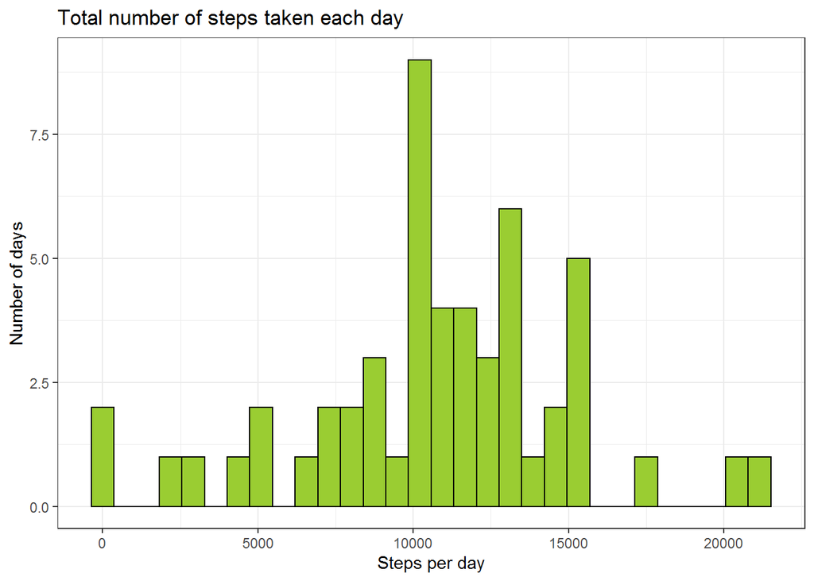

```r
Activity_SPD <- Activity %>% group_by(date) %>% summarize(SPD = sum(steps))
histogram <- ggplot(Activity_SPD, aes(x = SPD)) + geom_histogram(fill = 'yellowgreen', color = 'black') +
    labs(title = 'Total number of steps taken each day', x = 'Steps per day', y = 'Number of days') + theme_bw()
print(histogram)
```

```r
SPD_mean <- mean(Activity_SPD$SPD, na.rm = TRUE)
SPD_median <- median(Activity_SPD$SPD, na.rm = TRUE)
print(paste("The mean is: " ,SPD_mean))
```

```
## [1] "The mean is:  10766.1886792453"
```

```r
print(paste("The median is: " ,SPD_median))
```

```
## [1] "The median is:  10765"
```

```r
rm(Activity_SPD)
```